# Activity: Bird Species

Cael Walter

07/24/24

# Set Up

```r
# Load `tidyverse` and `dcData` packages
library(tidyverse)
# Load `tidyverse` and `dcData` packages
library(tidyverse)
library(dcData)
```

# Activity

When you’re finished with this activity, you will have a graph that shows what time of year various species appear at the Katherine Ordway Natural History Study Area in Inver Grove Heights, MN.

### Step 0

Before we begin, the book gives us some instructions to select a few key variables and clean up the date formatting. Use the commands given in the book, but be sure to study the functions used so you know what is happening. In this case, we select `SpeciesName`, `Month`, and `Day`. Then a `mutate()` command converts each variable to character, and then converts the resulting “character string” to a number.

|  | SpeciesName | Month | Day |
| --- | --- | --- | --- |
| 3 | Song Sparrow | 7 | 16 |
| 4 |  | NA | NA |
| 5 | Song Sparrow | 7 | 16 |
| 6 | Field Sparrow | 7 | 16 |
| 7 | Field Sparrow | 7 | 16 |
| 8 | Song Sparrow | 7 | 16 |

### Step 1

```r
# unique species in original data (including mis-spellings)
unique_species_original <- unique(OrdwayBirds$SpeciesName)
print(unique_species_original)

#Therer are 275 unique species in the original data.

# unique species in the clean list
unique_species_clean <- unique(OrdwayBirds$SpeciesName)
print(unique_species_clean)

#There is still 275 unique species in the clean list.
```

### Step 2

```r
install.packages("dplyr")
library(dplyr)

# Load the datasets
data("OrdwayBirds")
data("OrdwaySpeciesNames")




# inspect OrdwaySpeciesNames
head(OrdwaySpeciesNames)
summary(OrdwaySpeciesNames)
str(OrdwaySpeciesNames)

# inner join
OrdwayBirds_joined <- inner_join(OrdwayBirds, OrdwaySpeciesNames, by = "SpeciesName")




# inspect the data after the join
head(OrdwayBirds_joined)
summary(OrdwayBirds_joined)
str(OrdwayBirds_joined)
```

### Step 3

We want to identify the top 5-6 bird species sighted at the Katherine Ordway Natural History Study Area.

[output not shown]

[output cut: 990 more lines]

### Step 4

We now want to produce a month-by-month count for each of the major species, and then construct a chart to tell the story of what time of year the various species appear.

| SpeciesName | Month | count |
| --- | --- | --- |
| American Goldfinch | 1 | 10 |
| American Goldfinch | 10 | 364 |
| American Goldfinch | 11 | 180 |
| American Goldfinch | 12 | 3 |
| American Goldfinch | 2 | 51 |
| American Goldfinch | 3 | 48 |
| American Goldfinch | 4 | 21 |
| American Goldfinch | 5 | 125 |
| American Goldfinch | 6 | 63 |
| American Goldfinch | 7 | 67 |

[output cut: 31 more lines]

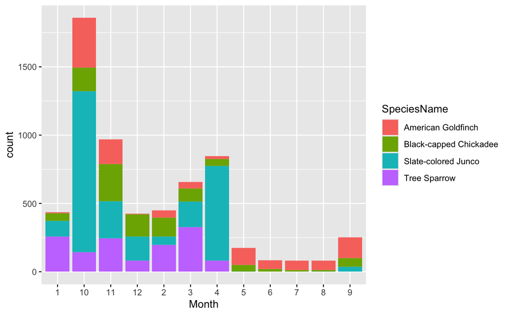

According to the graph, we can answer the questions posed:

##### 1. Which species are present year-round?

American Goldfinch: Present in most months, indicating year-round presence. Black-capped Chickadee: Present in most months, indicating year-round presence.

##### 3. What is the peak month for each major species? (bullet list)

American Goldfinch: Peak in month 10. Black-capped Chickadee: Peak in month 11. Slate-colored Junco: Peak in month 10. Tree Sparrow: Peaks in month 3.